# Debata pre zaciatocníkov (júlový turnus)

Zpět na rozcestník zpětné vazby | Tento report we Wordu | Data v CSV

## Hodnocení kurzu

Průměrná známka:

| Blok setkání | Průměrná známka |
| --- | --- |
| A | 1.38 |
| B | 1.06 |
| oba | 1.23 |

### Hodnocení po dnech

A a B jsou bloky (A je 9-10:30, B je 11-12:30)

Známky jsou jako ve škole: 1 je nejlepší, 5 nejhorší

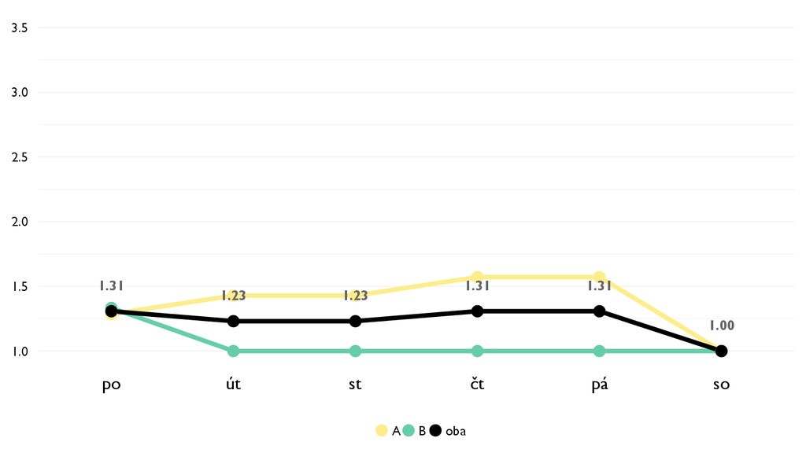

### Co se na kurzu líbilo

- Tomi a Zuzka nám vysvětlili podstatu argumentů a naučili mě přemýšlet víc do hloubky ;)
- Priateľský a zároveň profesionálny prístup lektorov, spůsob výučby( za každým vysvetlením množstvo príkladov v praxi, hry..) aj to,že sm eišli systematicky a že na konci sme si skúsili debatu. :)
- Lektoři byli milí, časté aktivity jako hry, to bylo moc super! A závěrečná debata, vyzkoušet si to:) a ta Nutella!
- Keď som na tento kurz šla, nevedela som o debate absolútne nič. Myslím, že som tam dostala dostatočn “začiatočnícky” prehľad. Naučili sme sa ako tvoriť argumenty, čo nepoužívať, ako má debata vyzerať a kurz sa zakončil debatou.
- Možnost naučit se debatovat, zjistit techniky, strukturu a hlavně si debatu nazávěr vyzkoušet. Líbila se mi vyuka, kde jsme si teorii později zkoušeli na příkladech a v praxi.
- Úžasná dvojica Tomi- Zuzka, ktorí nám nie len predviedli zohraný lektorský tím, ale tiež nás zabavili, cítili sme sa uvolnene, informovane a dobre nás naučili základy debaty.
- Dozvěděl jsem se, jak taková soutěžní debata vypadá, nejvíc mě tedy bavila poslední hodina.
- Dozvěděl jsem se a hlavně si vyzkoušel něco nového
- Nejvic se mi libila zaverecna debata, protoze jsme si mohli vyzkouset, jak to normalne probiha na debatach.
- Prístup lektorov. Aktivity, ktoré nám vymýšľali, motivovali nás a celkovo mali skvelý prístup, takže ma mnoho nového naučili.
- Příklady špatných argumentů. Přišlin mi trefně popsané.
- Všetko. Zuzka a Tomi boli úžasný. Páčila sa mi každá časť ich kurzu od tvorenia argumentov až po ich refutáciu.
- Popsani zacatku, hry

### Co na kurzu změnit

- Nevidím nic na měnění ;)
- Viac času naň :)
- Třeba pustit video debaty., nebo aby nám lektoři ukázali debatu.
- Klidně bych do kurzu zařadila debaty dvě, jednu na vyzkoušení a rozkoukání a další, kde už budeme vědět jak na to, budeme si více veřit.
- Možno niektoré veci preberať menej dookola a povedať nám z toho času, čo by tak ostal, nejaké ďalšie rady a veci o debate.
- Prostory, kde se vyučovalo byly trochu stísněné a pochmurné (mohli jsme častěji chodit ven), ale to je spíš drobnost. :)
- Forma byla vhodná, obsah a provedení též
- Interakci s pokročilými debatery.
- Aby boli dlhšie.

## Hodnocení lektora

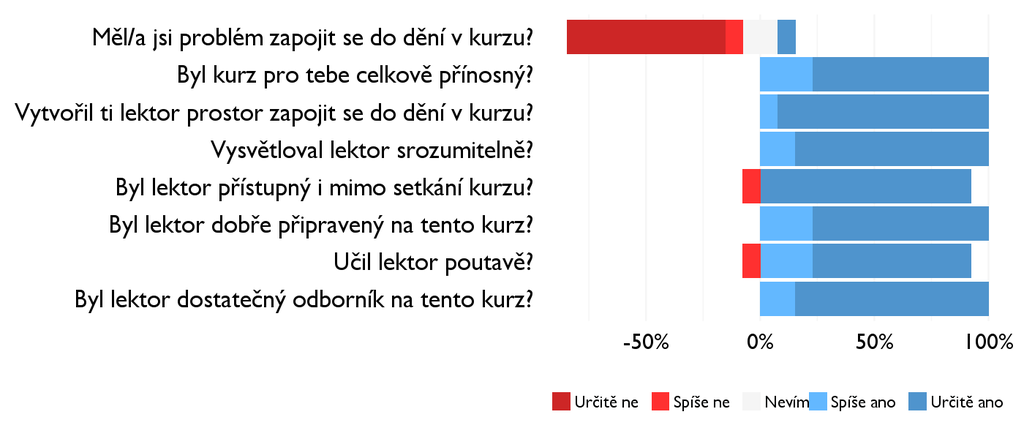

### Komentáře k lektorovi

- Len tak ďalej. :)
- Mohli by být více přístupnější, ale možná to jsou jen mé osobní pocity.
- Ďakujeme, ste obaja dokonalí, robte to ako doteraz…
- Super!

## Náročnost kurzu

### **Jak hodnotíš náročnost…**

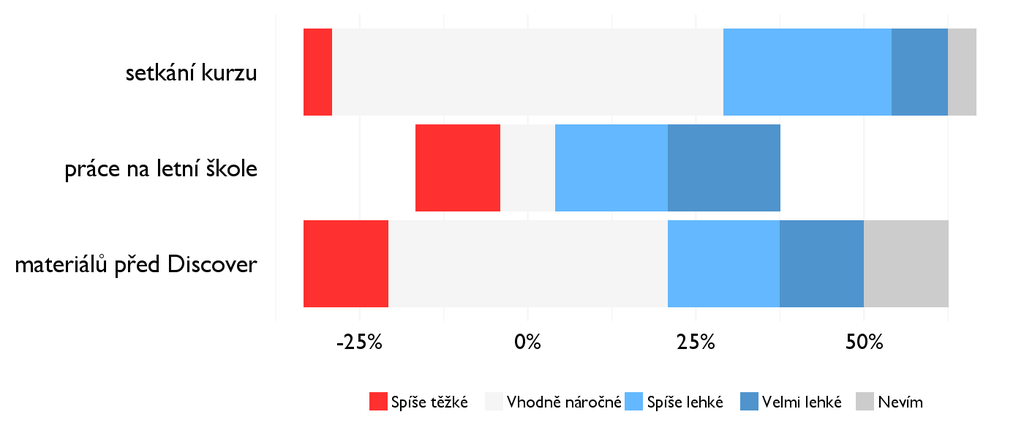

## Didaktika

Na některé otázky jsme se na augustovém turnuse neptali - tam uvidíte nadpis bez grafu.

### Jak lektor učí a měl by to změnit?

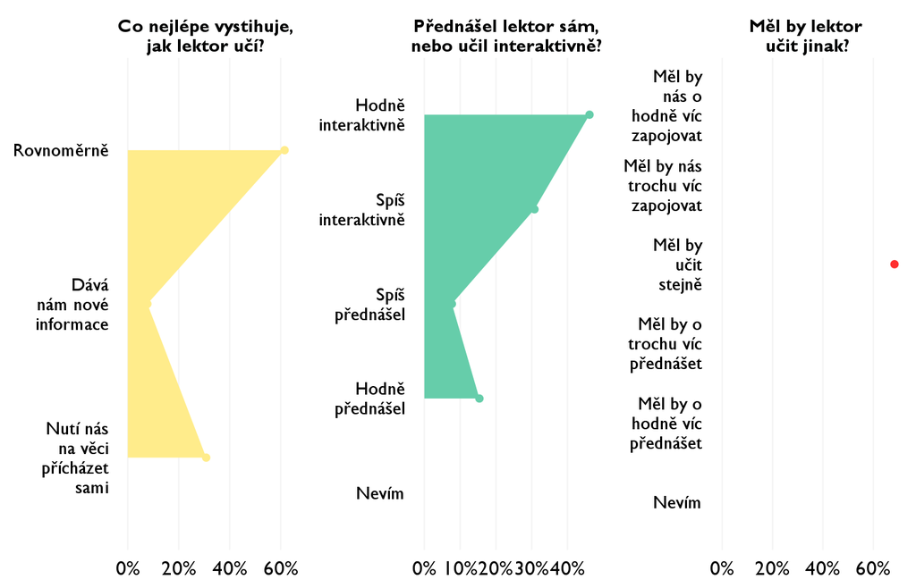

### Jak se studentům nejlépe učí?

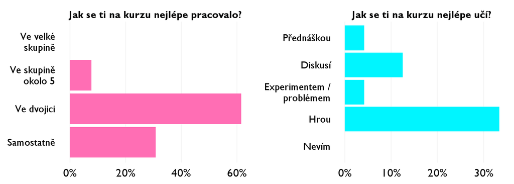

## Ovlivnil tě kurz nějak?

**Pokud ano, jak? Pokud ne, proč ne?**

- Naučil mě přemýšlet více do hloubky a neustále se ptát PROČ?
- Pozerám sa na problémy do hĺbky a z viacerých uhľov pohladu.
- Asi začnu 'závodně' debatovat.
- Rada by som sa venovala debate aj po Discoveru.
- Probudil ve mě zájem debatovat.
- určite áno. V mojich názoroch, v mojom vyjadrovaní, argumentovaní, istote…
- Uvažuji o tom, že se budu debatě věnovat ve svém volném čase. A i kdyby ne, tak budu nad diskusemi/hádkami více přemýšlet.
- Seznámil mě s úplně novou a velice zajímavou aktivitou
- Naucila jsem se lepe argumentovat.
- Debata ma oslovila ešte viac a najmä rozhodovanie.
- Díky němu jsem se začal zajímat o debatu.
- Ukázal mi, ako sa nebáť prejaviť názor na danú tému a následne si ho i obhájiť.
- Zacala jsem premyslet o argumentaci a smyslu argumentu, take o jejich strukture